# Likelihood and preference of domestic citations

Zuguang Gu ( z.gu@dkfz.de )

2024-12-04

```r
source("lib.R")

df = read.table("num_cite_country_country.tab", quote = "", sep = "\t", header = TRUE)
df = calc_stat(df, cutoff_total = 10000, cutoff_single = 100, all = TRUE)
df2 = df[df$country_cited == df$country_citing, ]
head(df2)
```

```
##      country_cited country_citing citations total_cited total_citing
## 340      Argentina      Argentina     33044      251784       296410
## 586      Australia      Australia    510342     3366179      2826952
## 785        Austria        Austria     86571      784203       777519
## 1127    Bangladesh     Bangladesh      5626       30987        65751
## 1458       Belgium        Belgium    101080     1211125       890806
## 2097        Brazil         Brazil    315328     1222739      1957467
##      global_citations    p_cited   p_citing p_global_cited p_global_citing
## 340         139760456 0.11148072 0.13123948   0.0018015396     0.002120843
## 586         139760456 0.18052730 0.15160869   0.0240853464     0.020227123
## 785         139760456 0.11134262 0.11039361   0.0056110507     0.005563226
## 1127        139760456 0.08556524 0.18156001   0.0002217151     0.000470455
## 1458        139760456 0.11347027 0.08345959   0.0086657202     0.006373806
## 2097        139760456 0.16108982 0.25788660   0.0087488195     0.014005872
##         expected  var_hyper p_hyper  log2_fc  z_score
## 340    533.99436   531.9019       0 5.951420 1409.618
## 586  68088.11826 65104.1370       0 2.905989 1733.275
## 785   4362.69850  4314.0847       0 4.310591 1251.617
## 1127    14.57799    14.5679       0 8.592174 1470.193
## 1458  7719.47551  7603.8047       0 3.710851 1070.651
## 2097 17125.52542 16737.9380       0 4.202633 2304.943
```

We use the following columns from `df2`:

- `country_cited` or `country_citing`: denoted as $A$.
- `citations`: total number of domestic citations, denoted as $k$.
- `total_cited`: total number of times $A$ is cited by the globe, denoted as $m_{A-}$.
- `total_citing`: total number of times $A$ cites in the globe, denoted as $n_{-A}$.
- `global_citations`: total number of citations in the globe, denoted as $N$.
- `p_cited`: for all citations made by $A$, fraction of $A$ itself being cited, $k/n_{-A}$.
- `p_citing`: for all citations $A$ receives, fraction of $A$ itself cites, $k/m_{A-}$.
- `p_global_cited`: fraction of global citations where $A$ is cited, $m_{A-}/N$.
- `p_global_citing`: fraction of global citations where $A$ cites, $n_{-A}/N$.

The four probabilities can be rephrased as:

- `p_cited`: given a reference from $A$, the probability of $A$ is cited, $P(A-|-A)$.
- `p_citing`: given a publication from $A$, the probability of being cited by $A$, $P(-A|A-)$.
- `p_global_cited`: the probability of $A$ is cited, $P(A-)$.
- `p_global_citing`: the probability of $A$ cites, $P(-A)$.

$P(A-|-A)$ and $P(-A|A-)$ are the likelihoods of $A$ is cited or cites given the corresponding publication/reference is also from $A$.

And the enrichment score $s$ can be written in one of the following two forms:

$$\begin{aligned}
s &= \log_2 P(A-|-A) - \log_2 P(A-) \\
s &= \log_2 P(-A|A-) - \log_2 P(-A) \\
\end{aligned}$$

It is easy to see, the enrichment score is the likelihood corrected by the global effect.

Next we directly look at the relations between the enrichment score and likelihood:

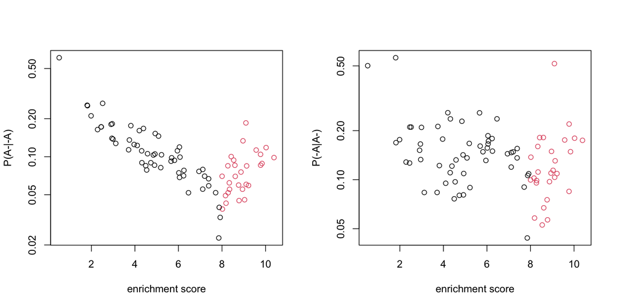

```r
l = df2$log2_fc > 8
par(mfrow = c(1, 2))
plot(df2$log2_fc, df2$p_cited, log = "y", xlab = "enrichment score", ylab = "P(A-|-A)",
    col = ifelse(l, 2, 1))
plot(df2$log2_fc, df2$p_citing, log = "y", xlab = "enrichment score", ylab = "P(-A|A-)",
    col = ifelse(l, 2, 1))
```

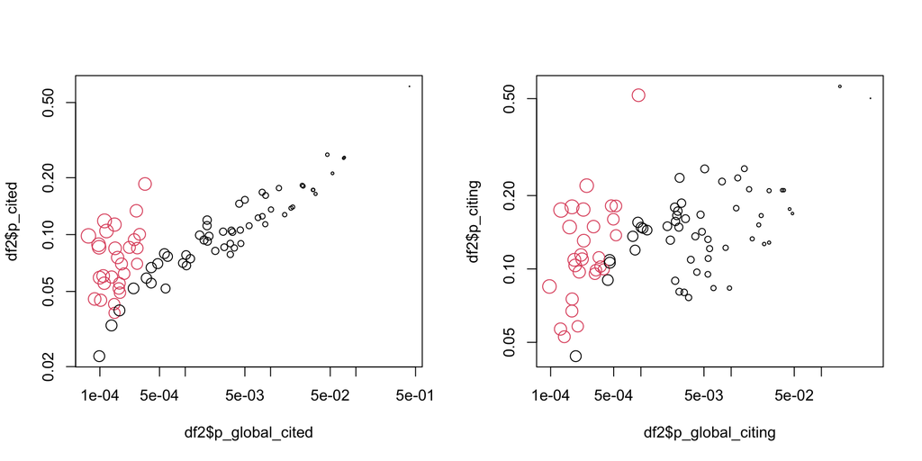

```r
par(mfrow = c(1, 2))
plot(df2$p_global_cited, df2$p_cited, log = "xy", cex = df2$log2_fc/5, col = ifelse(l, 2, 1))
plot(df2$p_global_citing, df2$p_citing, log = "xy", cex = df2$log2_fc/5, col = ifelse(l, 2, 1))
```

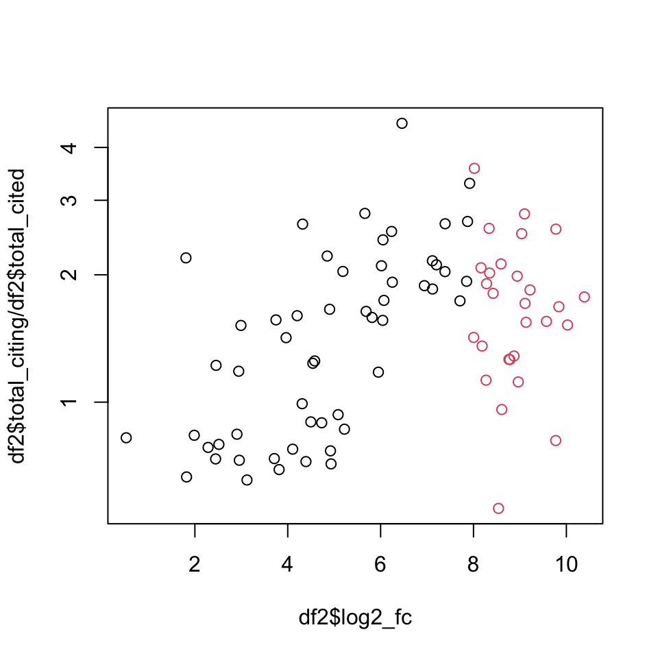

```r
plot(df2$log2_fc, df2$total_citing/df2$total_cited, log = "y", col = ifelse(l, 2, 1))
```